# ETC5512: Solutions for Lab 8

Emi Tanaka

Week 8

## 🏫 Exercise 8A

**Interrogate the PISA data**

```r
library(tidyverse)
library(haven)
pisa2018 <- readRDS(here::here("data", "pisa2018.rds")) %>%
   rename(country = CNT, sex = ST004D01T, birth_year = ST003D03T)
```

1. The number of students who participated by country/region is given below.

```r
pisa2018 %>%
   group_by(country) %>%
   tally() %>%  # shortcut for summarise(n = n())
   knitr::kable(col.names = c("Country", "Number of particpating students"))
```

| Country | Number of particpating students |
| --- | --- |
| Albania | 6359 |
| United Arab Emirates | 19277 |
| Argentina | 11975 |
| Australia | 14273 |
| Austria | 6802 |
| Belgium | 8475 |
| Bulgaria | 5294 |
| Bosnia and Herzegovina | 6480 |
| Belarus | 5803 |
| Brazil | 10691 |
| Brunei Darussalam | 6828 |
| Canada | 22653 |
| Switzerland | 5822 |
| Chile | 7621 |
| Colombia | 7522 |
| Costa Rica | 7221 |
| Czech Republic | 7019 |
| Germany | 5451 |
| Denmark | 7657 |
| Dominican Republic | 5674 |
| Spain | 35943 |
| Estonia | 5316 |
| Finland | 5649 |
| France | 6308 |
| United Kingdom | 13818 |
| Georgia | 5572 |
| Greece | 6403 |
| Hong Kong | 6037 |
| Croatia | 6609 |
| Hungary | 5132 |
| Indonesia | 12098 |
| Ireland | 5577 |
| Iceland | 3296 |
| Israel | 6623 |
| Italy | 11785 |
| Jordan | 8963 |
| Japan | 6109 |
| Kazakhstan | 19507 |
| Korea | 6650 |
| Kosovo | 5058 |
| Lebanon | 5614 |
| Lithuania | 6885 |
| Luxembourg | 5230 |
| Latvia | 5303 |
| Macao | 3775 |
| Morocco | 6814 |
| Moldova | 5367 |
| Mexico | 7299 |
| North Macedonia | 5569 |
| Malta | 3363 |
| Montenegro | 6666 |
| Malaysia | 6111 |
| Netherlands | 4765 |
| Norway | 5813 |
| New Zealand | 6173 |
| Panama | 6270 |
| Peru | 6086 |
| Philippines | 7233 |
| Poland | 5625 |
| Portugal | 5932 |
| Qatar | 13828 |
| Baku (Azerbaijan) | 6827 |
| B-S-J-Z (China) | 12058 |
| Moscow Region (RUS) | 2016 |
| Tatarstan (RUS) | 5816 |
| Romania | 5075 |
| Russian Federation | 7608 |
| Saudi Arabia | 6136 |
| Singapore | 6676 |
| Serbia | 6609 |
| Slovak Republic | 5965 |
| Slovenia | 6401 |
| Sweden | 5504 |
| Chinese Taipei | 7243 |
| Thailand | 8633 |
| Turkey | 6890 |
| Ukraine | 5998 |
| Uruguay | 5263 |
| United States | 4838 |
| Vietnam | 5377 |

```r
ncountry <- length(unique(pisa2018$country))

compute_diff <- function(sex, score, weight) {
   df <- tibble(sex = droplevels(sex), score, weight)
   df %>%
      group_by(sex) %>%
      summarise(avg = weighted.mean(score, weight)) %>%
      pivot_wider(names_from = sex, values_from = avg) %>%
      mutate(diff = Female - Male) %>%
      pull(diff)
}

bootstrap_ci <- function(sex, score, weight, times = 100) {
   df <- tibble(sex = droplevels(sex), score, weight)
   avg <- compute_diff(sex, score, weight)
   boot_means <- map_dbl(1:times, ~{
         boot_df <- df %>%
           # resample within sex so that the number of girls & boys remain the same
           group_by(sex) %>%
           sample_n(size = n(), replace = TRUE)
         with(boot_df, compute_diff(sex, score, weight))
      })
   setNames(c(avg, sort(boot_means)[c(5, 95)]), c("avg", "lower", "upper"))
}
```

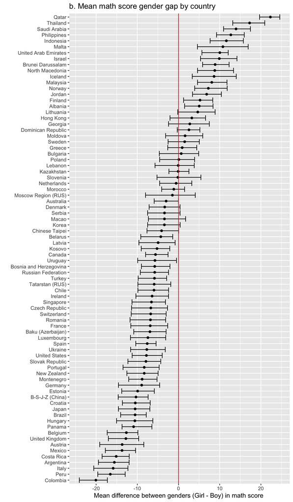

```r
math_df <- pisa2018 %>%
   filter(!is.na(sex) & !is.na(PV1MATH)) %>%
   group_by(country) %>%
   summarise(math_ci = list(bootstrap_ci(sex, PV1MATH, SENWT))) %>%
   unnest_wider(math_ci) %>%
   ungroup() %>%
   mutate(country = fct_reorder(country, avg))

ggplot(math_df, aes(avg, country)) +
   geom_point() +
   geom_errorbar(aes(xmin = lower,
                     xmax = upper)) +
   geom_vline(xintercept = 0, color = "red") +
   labs(title = "b. Mean math score gender gap by country",
        y = "", x = "Mean difference between genders (Girl - Boy) in math score ")
```

(c) The number of students who conducted the test with `BOOKID` as Form 1-12 or 67-78 (i.e. the number of students who sat for a test that included a maths component) by each country are given below.

```r
pisa2018 %>%
   filter(BOOKID %in% paste("Form", c(1:12, 67:78))) %>%
   group_by(country) %>%
   tally() %>%
   knitr::kable(col.names = c("Country", "Number of students who undertook the maths component"))
```

| Country | Number of students who undertook the maths component |
| --- | --- |
| Albania | 2255 |
| United Arab Emirates | 8854 |
| Argentina | 5238 |
| Australia | 6508 |
| Austria | 3104 |
| Belgium | 3763 |
| Bulgaria | 2455 |
| Bosnia and Herzegovina | 2934 |
| Belarus | 2681 |
| Brazil | 4908 |
| Brunei Darussalam | 2400 |
| Canada | 7647 |
| Switzerland | 2679 |
| Chile | 2657 |
| Colombia | 2638 |
| Costa Rica | 2302 |
| Czech Republic | 3199 |
| Germany | 2482 |
| Denmark | 3304 |
| Dominican Republic | 2606 |
| Spain | 12602 |
| Estonia | 2467 |
| Finland | 2573 |
| France | 2880 |
| United Kingdom | 6042 |
| Georgia | 2563 |
| Greece | 2246 |
| Hong Kong | 2130 |
| Croatia | 2287 |
| Hungary | 2361 |
| Indonesia | 4215 |
| Ireland | 2581 |
| Iceland | 1485 |
| Israel | 2410 |
| Italy | 5475 |
| Jordan | 3944 |
| Japan | 2814 |
| Kazakhstan | 6848 |
| Korea | 2338 |
| Kosovo | 2313 |
| Lebanon | 2455 |
| Lithuania | 2405 |
| Luxembourg | 2407 |
| Latvia | 1857 |
| Macao | 1742 |
| Morocco | 2378 |
| Moldova | 2363 |
| Mexico | 3363 |
| North Macedonia | 2429 |
| Malta | 1186 |
| Montenegro | 3066 |
| Malaysia | 2797 |
| Netherlands | 1787 |
| Norway | 2679 |
| New Zealand | 2821 |
| Panama | 2197 |
| Peru | 2792 |
| Philippines | 2528 |
| Poland | 2577 |
| Portugal | 2730 |
| Qatar | 6380 |
| Baku (Azerbaijan) | 3155 |
| B-S-J-Z (China) | 5555 |
| Moscow Region (RUS) | 691 |
| Tatarstan (RUS) | 2035 |
| Romania | 2225 |
| Russian Federation | 2675 |
| Saudi Arabia | 2705 |
| Singapore | 2333 |
| Serbia | 2302 |
| Slovak Republic | 2032 |
| Slovenia | 2863 |
| Sweden | 2539 |
| Chinese Taipei | 2527 |
| Thailand | 3023 |
| Turkey | 3172 |
| Ukraine | 2624 |
| Uruguay | 2412 |
| United States | 2218 |
| Vietnam | 2356 |

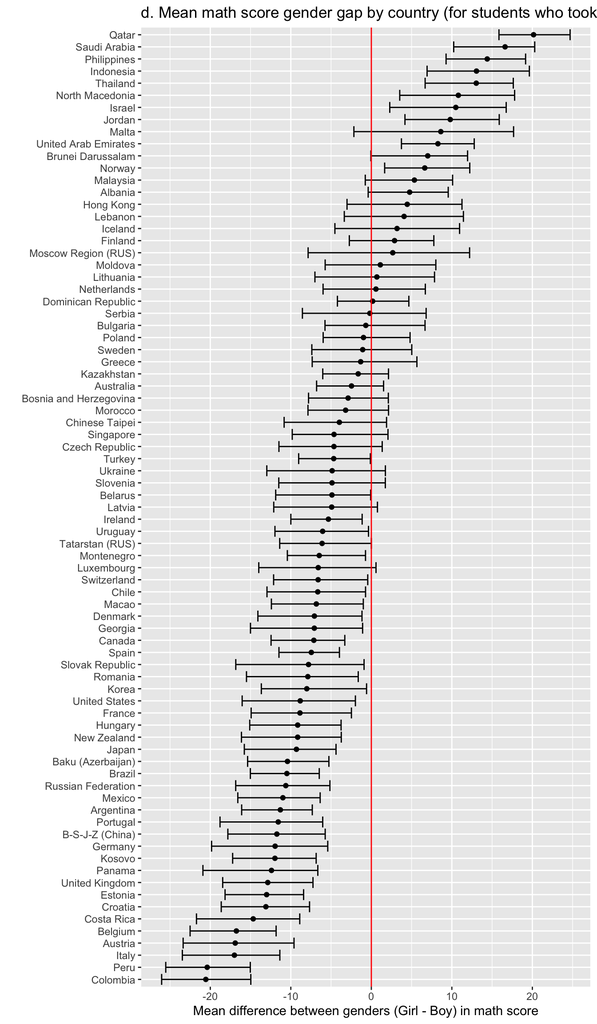

```r
math2_df <- pisa2018 %>%
   filter(!is.na(sex) & !is.na(PV1MATH)) %>%
   filter(BOOKID %in% paste("Form", c(1:12, 67:78))) %>%
   group_by(country) %>%
   summarise(math_ci = list(bootstrap_ci(sex, PV1MATH, SENWT))) %>%
   unnest_wider(math_ci) %>%
   ungroup() %>%
   mutate(country = fct_reorder(country, avg))

ggplot(math2_df, aes(avg, country)) +
   geom_point() +
   geom_errorbar(aes(xmin = lower,
                     xmax = upper)) +
   geom_vline(xintercept = 0, color = "red") +
   labs(title = "d. Mean math score gender gap by country (for students who took the maths test)",
        y = "", x = "Mean difference between genders (Girl - Boy) in math score")
```

## 👨‍🎓 Exercise 8B

From the plots we can see that girls in general perform better than boys in reading and science!

```r
scie_df <- pisa2018 %>%
   filter(!is.na(sex) & !is.na(PV1SCIE)) %>%
   group_by(country) %>%
   summarise(scie_ci = list(bootstrap_ci(sex, PV1SCIE, SENWT))) %>%
   unnest_wider(scie_ci) %>%
   ungroup() %>%
   mutate(country = fct_reorder(country, avg))
```

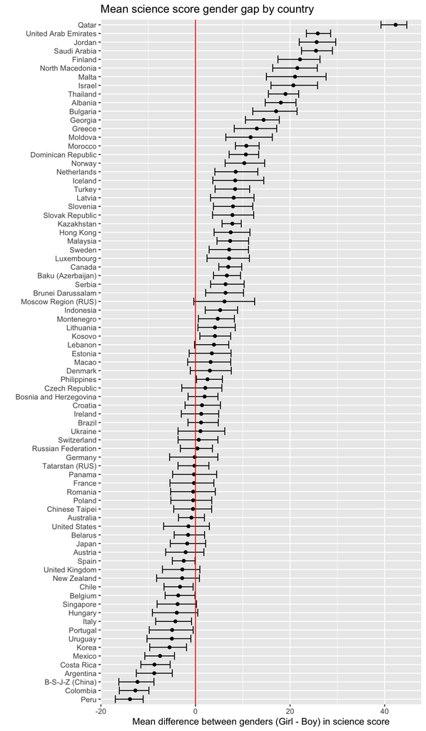

```r
ggplot(scie_df, aes(avg, country)) +
   geom_point() +
   geom_errorbar(aes(xmin = lower,
                     xmax = upper)) +
   geom_vline(xintercept = 0, color = "red") +
   labs(title = "Mean science score gender gap by country",
        y = "", x = "Mean difference between genders (Girl - Boy) in science score")
```

```r
read_df <- pisa2018 %>%
   filter(!is.na(sex) & !is.na(PV1READ)) %>%
   group_by(country) %>%
   summarise(read_ci = list(bootstrap_ci(sex, PV1READ, SENWT))) %>%
   unnest_wider(read_ci) %>%
   ungroup() %>%
   mutate(country = fct_reorder(country, avg))
```

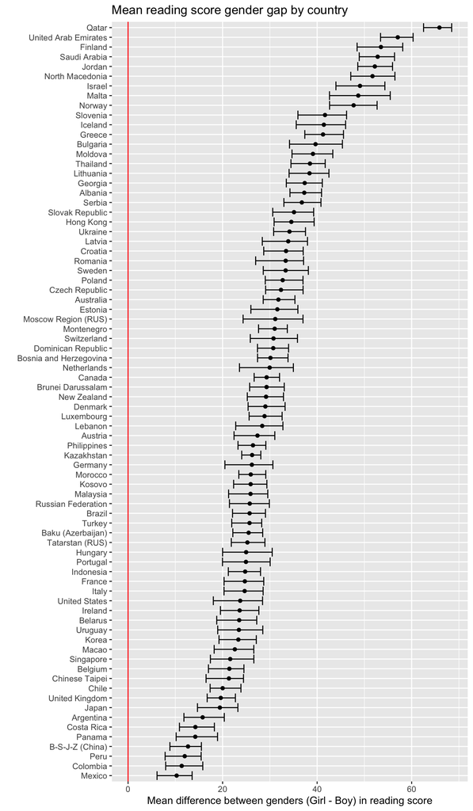

```r
ggplot(read_df, aes(avg, country)) +
   geom_point() +
   geom_errorbar(aes(xmin = lower,
                     xmax = upper)) +
   geom_vline(xintercept = 0, color = "red") +
   labs(title = "Mean reading score gender gap by country",
        y = "", x = "Mean difference between genders (Girl - Boy) in reading score")
```

## 👩‍🏫 Exercise 8C

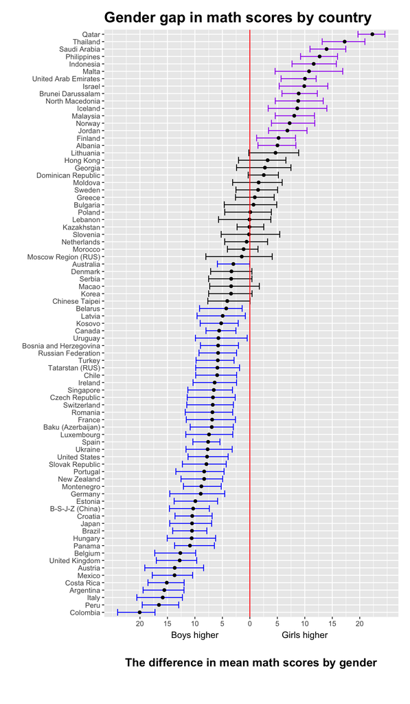

```r
math_df %>%
   mutate(color = case_when(
      avg > 0 & lower > 0 ~ "purple",
      avg < 0 & upper < 0 ~ "blue",
      TRUE ~ "black"
   )) %>%
   ggplot(aes(avg, country)) +
   geom_errorbar(aes(xmin = lower,
                     xmax = upper,
                     color = I(color))) +
   geom_point() +
   geom_vline(xintercept = 0, color = "red") +
   labs(x = "The difference in mean math scores by gender",
        y = "") +
   scale_x_continuous(breaks = seq(-20, 20, by = 5),
                      labels = c(seq(20, 0, by = -5), seq(5, 20, by = 5))) +
   annotate("text", label = c("Boys higher", "Girls higher"),
            x = c(-10, 10), y = -2) +
   ggtitle("Gender gap in math scores by country") +
   coord_cartesian(clip = "off", ylim = c(1, ncountry - 1)) +
   theme(plot.margin = unit(c(1,1,3,1), "lines"),
         axis.title.x = element_text(size = 14, face = "bold", margin = unit(c(3, 0, 0, 0), "lines")),
         plot.title = element_text(size = 18, face = "bold"))
```

## 👨‍🎓 Exercise 8D

```r
set.seed(2020)
b0 <- 1 # true intercept
b1 <- 2 # true slope
gvec <- 1:4 # true effects by category
n <- 20 # number of observations
sim_df <- tibble(id = 1:n) %>%
   mutate(       x = runif(n(), 0, 10),                             # making the continuous variable
          category = factor(rep(c("A", "B", "C", "D"), each = n/4)), # making the categorical variable
                y1 = b0 + b1 * x + rnorm(n(), 0, 1),                              # data 1
                y2 = gvec[as.numeric(category)] + rnorm(n(), 0, 1))    # data 2
```

```r
est1 <- coef(lm(y1 ~ x, data = sim_df))
est2 <- coef(lm(y2 ~ -1 + category, data = sim_df))
```

1. The least squares estimates of the model parameters are: $\hat{\beta}_0 =$ 0.6518651, $\hat{\beta}_1 =$ 2.1320736, $\hat{\gamma}_1 =$ 1.4725261, $\hat{\gamma}_2 =$ 1.9935868, $\hat{\gamma}_3 =$ 2.6392649 and $\hat{\gamma}_4 =$ 4.2106761.
2. The least squares estimates of the model parameters if we increase the sample size from 20 to 1000 are: $\hat{\beta}_0 =$ 1.0599084, $\hat{\beta}_1 =$ 1.9936022, $\hat{\gamma}_1 =$ 0.9716031, $\hat{\gamma}_2 =$ 1.8721459, $\hat{\gamma}_3 =$ 2.9733664 and $\hat{\gamma}_4 =$ 3.9155304. These values are much closer to the true values than when the sample size was 20.

```r
n <- 1000 # number of observations
sim2_df <- tibble(id = 1:n) %>%
   mutate(       x = runif(n(), 0, 10),                             # making the continuous variable
          category = factor(rep(c("A", "B", "C", "D"), each = n/4)), # making the categorical variable
                y1 = b0 + b1 * x + rnorm(n(), 0, 1),                              # data 1
                y2 = gvec[as.numeric(category)] + rnorm(n(), 0, 1))    # data 2

est1v2 <- coef(lm(y1 ~ x, data = sim2_df))
est2v2 <- coef(lm(y2 ~ -1 + category, data = sim2_df))
```

## 📚 Exercise 8E

**Visual inference**

```
## decrypt("E0Ui w676 VQ rnqV7VnQ 2O")
```

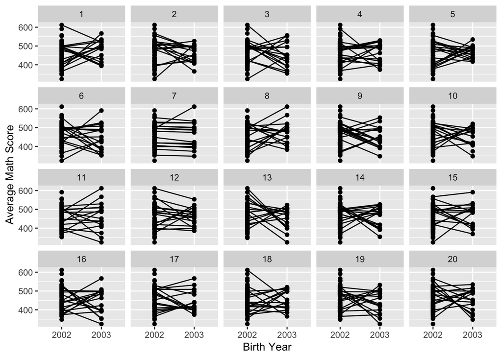

```r
library(nullabor)
set.seed(2020)

df <- pisa2018 %>%
   filter(!is.na(birth_year)) %>%
   mutate(birth_year = as.character(birth_year)) %>%
   group_by(country, birth_year) %>%
   summarise(math_score = weighted.mean(PV1MATH, SENWT, na.rm = T)) %>%
   filter(birth_year != 2001 ) %>%   # since only one country
   ungroup()


lineup(null_permute("math_score"), df) %>%
   ggplot(aes(birth_year, math_score, group = country)) +
   geom_point() +
   geom_line() +
   facet_wrap(~.sample) +
   labs(x = "Birth Year", y = "Average Math Score")
```

```r
decrypt("E0Ui w676 VQ rnqV7VnQ 2O")
```

```
## [1] "True data in position  7"
```